# Difference in Win Percentage Between Home and Away Games in Basketball Through the Years

Takeshi Sui 12/16/2022

# Introduction and Motivation

In every sports league, when two teams are set to play against each other, there must be a decision made between which of the two teams' playing field the game is played in. Almost every sports team have a stadium or arena located in the city that the team is based in. For example, the New York Knicks is located in New York City and their sports arena the Madison Square Garden is located in the same city. Similarly, the Los Angeles Lakers is located in Los Angeles and their sports arena the Staples Center is also located in the same city. When a team plays a game in the arena located in their city, it is considered a home game, and when a team plays a game in the opponent team's arena, it is considered an away game. Historically, teams have had a lower winning percentage when playing in the opponent teams' arenas due to reasons including fatigue from travel, worse living accomodations, and lack of fans in the crowd. However, as technology and standard of living have improved through the years, the gap of winning percentages between home and away games have supposedly decreased. It has always fascinated me that a team can play at vastly different skill levels just by being at a different location. I have been wanting to explore more about this topic and see if time has made a difference in this disparity.

```python
import sqlite3
import pandas
import numpy as np
import matplotlib.pyplot as plt
import scipy.stats as stats
```

# The Process

**1. The Dataset Used** The dataset I used comes from Kaggle (https://www.kaggle.com/datasets/wyattowalsh/basketball) and was compiled by a user named Wyatt Walsh. The dataset contains data from the league's conception in 1946 until 2020 on all nba games, teams, and players including over 60,000 games with box scores, information of current and past teams, and over 4,500 players' information throughout their career. The SQL database includes 16 different tables, but I only used one of these which is the table that includes every game played since 1946. The original dataset includes 149 features, but I am only utilizing five of them in this project:

1. Season ID - the season the game was played in
2. Team Name Home - the name of the home team that played in the game
3. WL Home - whether the home team won the game or not (W = win, L = loss)
4. Team Name Away - the name of the away team that played in the game
5. WL Away - whether the away team won the game or not (W = win, L = loss)

**2. Data Loading and Pre-processing** For this project, I decided to focus on arguably the three most iconic teams in the NBA which are also the teams that have been a part of the league for the longest time: the New York Knicks, the Los Angeles Lakers, and the Boston Celtics. Since all the data is stored in an SQL database, I used a query to get the table I want and store it into a pandas dataframe. Then I removed all the columns that I don't need for this project.

```python
#create connection to SQL database
sqlite_file = 'basketball.sqlite'
conn = sqlite3.connect(sqlite_file)

#Create the query
query = "SELECT * FROM Game"

#Store the Game table into a pandas dataframe
df = pandas.read_sql(query, conn)
df = df[['SEASON_ID', 'TEAM_NAME_HOME', 'WL_HOME', 'TEAM_NAME_AWAY', 'WL_AWAY']]

df.head()
```

|  | SEASON_ID | TEAM_NAME_HOME | WL_HOME | TEAM_NAME_AWAY | WL_AWAY |
| --- | --- | --- | --- | --- | --- |
| 0 | 21946 | Toronto Huskies | L | New York Knicks | W |
| 1 | 21946 | St. Louis Bombers | W | Pittsburgh Ironmen | L |
| 2 | 21946 | Chicago Stags | W | New York Knicks | L |
| 3 | 21946 | Providence Steamrollers | W | Boston Celtics | L |
| 4 | 21946 | Detroit Falcons | L | Washington Capitols | W |

Thankfully, there are no missing values in our dataset, so we can go straight into organizing our data. I first created a dictionary for each of the three teams to store the number of wins and losses in their home and away games each season. Notice that the Lakers didn't become a team in the NBA until 1948 so I had to delete the first two elements of the dictionary.

The next step is to simply iterate through the dataframe and count the number of wins and losses for each team. It is important to note that in 1960, the Lakers basketball team moved from the city of Minneapolis to Los Angeles which is where they are now. As a result, the official team name changed from the Minneapolis Lakers to the Los Angeles Lakers. To take this into account I simply checked if the team name contained the string "lakers" since the name "lakers" remained the same before and after the move.

```python
#Initialize dictionaries for all three teams
lakers = {}
celtics = {}
knicks = {}

for season in df["SEASON_ID"].unique():
    lakers.update({season: [0, 0, 0, 0]})
    celtics.update({season: [0, 0, 0, 0]})
    knicks.update({season: [0, 0, 0, 0]})

#Delete the first two years when Lakers haven't been formed
del lakers["21946"]
del lakers["21947"]

#Count number of wins and losses for each team each season
for i, row in df.iterrows():
    if "Lakers" in row["TEAM_NAME_HOME"]:
        if row["WL_HOME"] == "W":
            lakers[row["SEASON_ID"]][0] += 1
        else:
            lakers[row["SEASON_ID"]][1] += 1
    elif "Lakers" in row["TEAM_NAME_AWAY"]:
        if row["WL_AWAY"] == "W":
            lakers[row["SEASON_ID"]][2] += 1
        else:
            lakers[row["SEASON_ID"]][3] += 1

    if "Celtics" in row["TEAM_NAME_HOME"]:
        if row["WL_HOME"] == "W":
            celtics[row["SEASON_ID"]][0] += 1
        else:
            celtics[row["SEASON_ID"]][1] += 1
    elif "Celtics" in row["TEAM_NAME_AWAY"]:
        if row["WL_AWAY"] == "W":
            celtics[row["SEASON_ID"]][2] += 1
        else:
            celtics[row["SEASON_ID"]][3] += 1

    if "Knicks" in row["TEAM_NAME_HOME"]:
        if row["WL_HOME"] == "W":
            knicks[row["SEASON_ID"]][0] += 1
        else:
            knicks[row["SEASON_ID"]][1] += 1
    elif "Knicks" in row["TEAM_NAME_AWAY"]:
        if row["WL_AWAY"] == "W":
            knicks[row["SEASON_ID"]][2] += 1
        else:
            knicks[row["SEASON_ID"]][3] += 1
```

Finally, now that we have information on the number of wins and losses for home and away games for each season the three teams existed in the NBA, we can calculate the win percentages of each of the teams when they played at home vs when they played in away games. For each team, I iterated through the dictionary created in the previous step, and for each season, I took the number wins and divided it by the total number of games they played. I did this for both the home and away games. I also calculated the difference in win percentage between home and away games for each season. I did this by simply taking the win percentage at home and subtracting it by the win percentage at away games.

Here I calculate the win percentages for the New York Knicks:

```python
knicks_home = []
knicks_away = []
knicks_difference = []

knicks_years = range(1946, 2021)

for n in knicks.values():
    knicks_home.append(n[0] / (n[0] + n[1]) * 100)
    knicks_away.append(n[2] / (n[2] + n[3]) * 100)
    knicks_difference.append((n[0] / (n[0] + n[1]) * 100) - (n[2] / (n[2] + n[3]) * 100))
```

Here I calculate the win percentages for the Boston Celtics:

```python
celtics_home = []
celtics_away = []
celtics_difference = []

celtics_years = range(1946, 2021)

for n in celtics.values():
    celtics_home.append(n[0] / (n[0] + n[1]) * 100)
    celtics_away.append(n[2] / (n[2] + n[3]) * 100)
    celtics_difference.append((n[0] / (n[0] + n[1]) * 100) - (n[2] / (n[2] + n[3]) * 100))
```

Here I calculated the win percentages for the Los Angeles Lakers (Previously the Minneapolis Lakers):

```python
lakers_home = []
lakers_away = []
lakers_difference = []

lakers_years = range(1948, 2021)

for n in lakers.values():
    lakers_home.append(n[0] / (n[0] + n[1]) * 100)
    lakers_away.append(n[2] / (n[2] + n[3]) * 100)
    lakers_difference.append((n[0] / (n[0] + n[1]) * 100) - (n[2] / (n[2] + n[3]) * 100))
```

**3. Exploratory Data Analysis** After preprocessing and organizing our data, we can now create graphs and charts to be able to visualize our data better. To start off, I created double bar graphs for each team with one bar displaying the win percentage at home and one bar displaying the win percentage at away games. There is a pair of bars for each season that the team played in the NBA.

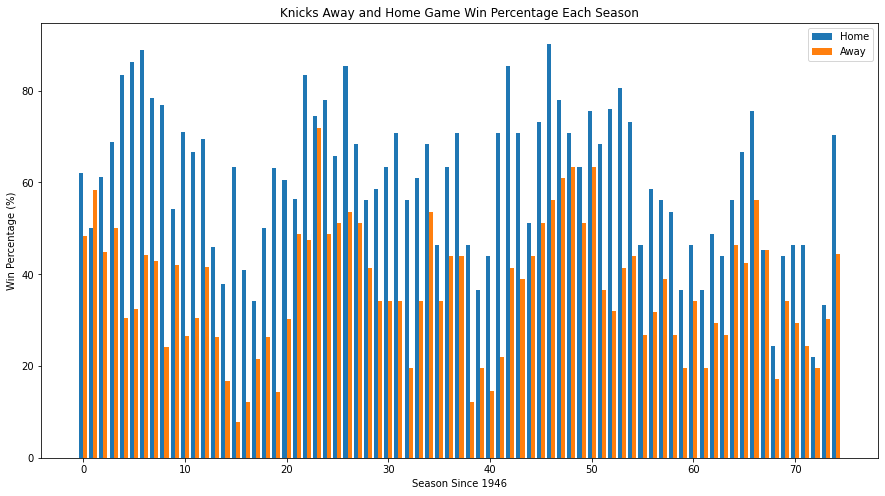

```python
X_axis = np.arange(len(knicks_years))

plt.figure(figsize = (15, 8))

plt.title('Knicks Away and Home Game Win Percentage Each Season')
plt.ylabel('Win Percentage (%)')
plt.xlabel('Season Since 1946')

plt.bar(X_axis - 0.2, knicks_home, 0.4, label = 'Home')
plt.bar(X_axis + 0.2, knicks_away, 0.4, label = 'Away')

plt.legend(loc="upper right")
```

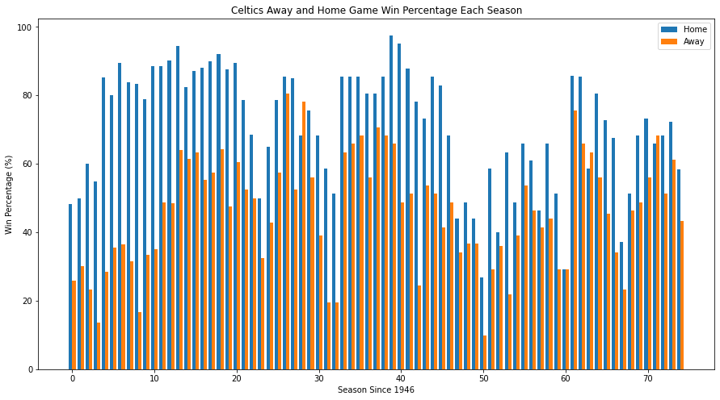

```python
X_axis = np.arange(len(celtics_years))

plt.figure(figsize = (15, 8))

plt.title('Celtics Away and Home Game Win Percentage Each Season')
plt.ylabel('Win Percentage (%)')
plt.xlabel('Season Since 1946')

plt.bar(X_axis - 0.2, celtics_home, 0.4, label = 'Home')
plt.bar(X_axis + 0.2, celtics_away, 0.4, label = 'Away')

plt.legend(loc="upper right")
```

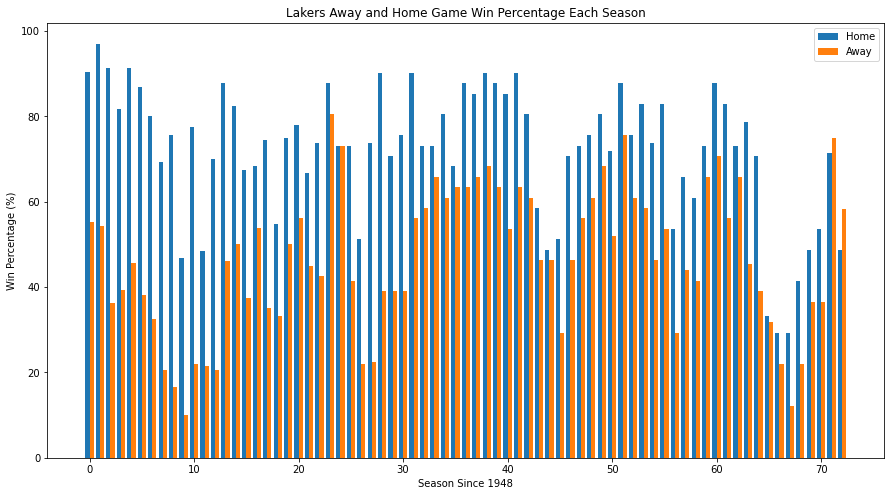

```python
X_axis = np.arange(len(lakers_years))

plt.figure(figsize = (15, 8))

plt.title('Lakers Away and Home Game Win Percentage Each Season')
plt.ylabel('Win Percentage (%)')
plt.xlabel('Season Since 1948')

plt.bar(X_axis - 0.2, lakers_home, 0.4, label = 'Home')
plt.bar(X_axis + 0.2, lakers_away, 0.4, label = 'Away')

plt.legend(loc="upper right")
```

Looking at these graphs, we can clearly see that for all three teams, the winning percentage at home is much higher on average than the winning percentage at away games. It is interesting to note that the for the last couple of years, especially in 2020, the Los Angeles Lakers actually had a higher winning percentage at away games than home games. A very plausible explanation for this could be that a portion of that season's games were played at the Disney resort in Orlando, Florida due to the pandemic. Toward the end of the season, every nba team that still had a chance to make playoffs were brought together inside a bubble where they would play the remaining games that season in the same arena without in person attendance by fans.

Overall, we can definitely see that early on in the 40s, 50s, 60s, and even the 70s, the discrepancy between the winning percentages of home and away games was very high. If we compare that to season in the 2000s and 2010s, we can see that in more recent seasons, there is less of a discrepancy between the winning at home vs away.

To more accurately and visually represent this information, I created a scatterplot for each team where every plot represents the difference in winning percentage between home and away games that season. For each plot I added a regression line to see the overall trend.

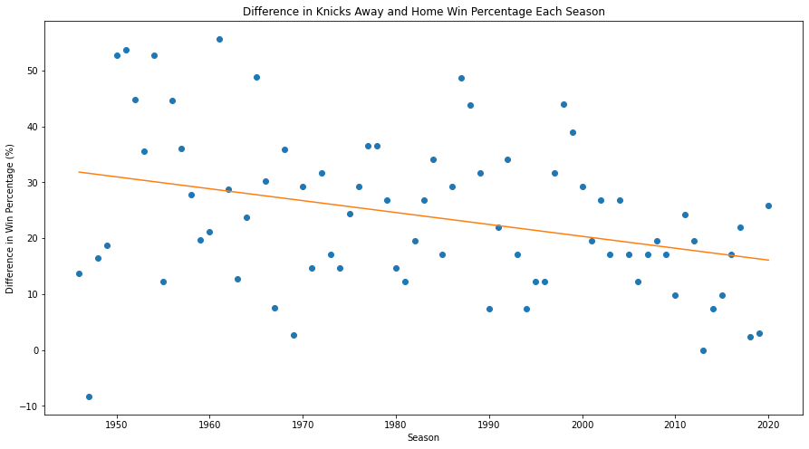

```python
plt.figure(figsize = (15, 8))
plt.title('Difference in Knicks Away and Home Win Percentage Each Season')
plt.ylabel('Difference in Win Percentage (%)')
plt.xlabel('Season')
plt.plot(knicks_years, knicks_difference, 'o')
m, b = np.polyfit(knicks_years, knicks_difference, 1)
plt.plot(knicks_years, m*knicks_years+b)
```

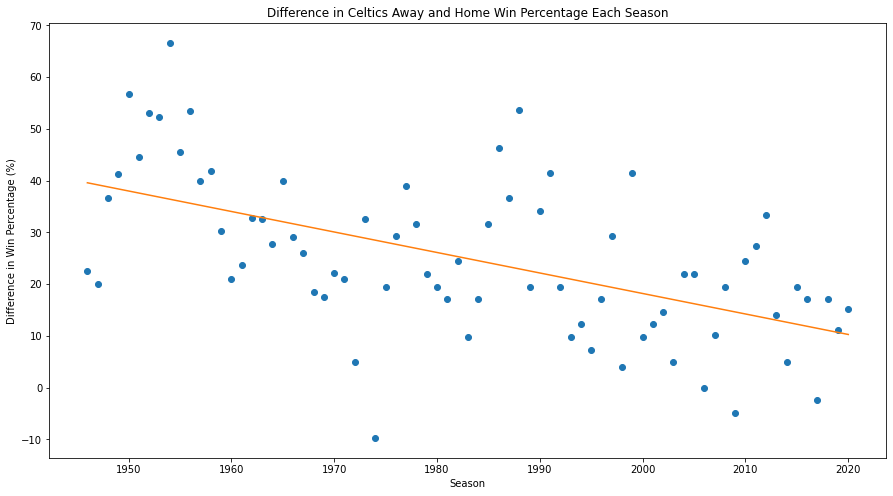

```python
plt.figure(figsize = (15, 8))
plt.title('Difference in Celtics Away and Home Win Percentage Each Season')
plt.ylabel('Difference in Win Percentage (%)')
plt.xlabel('Season')
plt.plot(celtics_years, celtics_difference, 'o')
m, b = np.polyfit(celtics_years, celtics_difference, 1)
plt.plot(celtics_years, m*celtics_years+b)
```

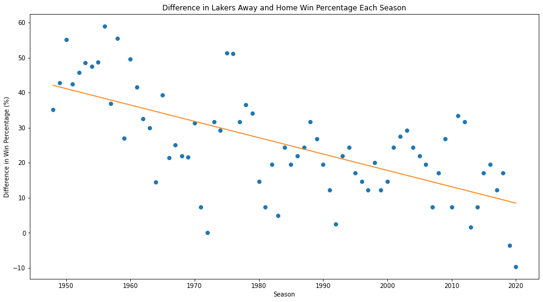

```python
plt.figure(figsize = (15, 8))
plt.title('Difference in Lakers Away and Home Win Percentage Each Season')
plt.ylabel('Difference in Win Percentage (%)')
plt.xlabel('Season')
plt.plot(lakers_years, lakers_difference, 'o')
m, b = np.polyfit(lakers_years, lakers_difference, 1)
plt.plot(lakers_years, m*lakers_years+b)
```

**4. Hypothesis Testing** For the last part of this project, we will use hypothesis testing to formally conclude if there was a significant enough difference in the winning percentage between home and away games. More crucially, we want to see if the difference in winning percentage have signficantly changed from the start of the NBA to the current NBA.

To start off, we want to first test if there is a signficant enough difference in winning percentage between home and away games. To perform this test, I used paired T-test since we have the same sample, but we are taking data from two different categories: games played at home and games played away. I performed this test once for the first 20 years of the NBA and once for the last 10 years of the NBA. For both tests, I combined the data for all three teams. Note that for the Lakers, I only did the first 18 years since they were not a part of the league in 1946 and 1947.

```python
past_home = []
past_away = []

past_home.extend(knicks_home[0:20])
past_home.extend(celtics_home[0:20])
past_home.extend(lakers_home[0:18])
past_away.extend(knicks_away[0:20])
past_away.extend(celtics_away[0:20])
past_away.extend(lakers_away[0:18])

stats.ttest_rel(past_home, past_away)
```

```
Ttest_relResult(statistic=18.88947090772941, pvalue=3.285894870937929e-26)
```

After doing the test for the first 20 years of the NBA, we get an astronomically small p-value. Even if we choose a significance level of 0.01 for this test, we are still able to reject the null hypothesis that there is not a significant difference between winning percentages at home vs at away games.

```python
present_home = []
present_away = []

present_home.extend(knicks_home[-10:])
present_home.extend(celtics_home[-10:])
present_home.extend(lakers_home[-10:])
present_away.extend(knicks_away[-10:])
present_away.extend(celtics_away[-10:])
present_away.extend(lakers_away[-10:])

stats.ttest_rel(present_home, present_away)
```

```
Ttest_relResult(statistic=6.76598792246629, pvalue=1.9955753002962043e-07)
```

For the last 10 years of the NBA, although we get a pvalue that is larger, it is still exponentially smaller than a value of 0.01 if we set that as our significance level. So we also reject the null hypothesis here that there is not a significant difference between winning percentages at home vs at away games.

Although we have concluded that there is in fact a significant difference between winning percentages at home vs away, we need to see if this difference has changed over the years. To do this, we are going to take the difference in winning percentage of the first 20 years of the league and compare to the difference in winning percentage of the last 20 years of the league. Here, we are going to perform a two sample T-test as opposed to a paired T-test because our data is no longer one-to-one paired, but it is from two different samples.

```python
past_difference = []
present_difference = []

past_difference.extend(knicks_difference[0:20])
past_difference.extend(celtics_difference[0:20])
past_difference.extend(lakers_difference[0:18])
present_difference.extend(knicks_difference[-20:])
present_difference.extend(celtics_difference[-20:])
present_difference.extend(lakers_difference[-20:])

stats.ttest_ind(a=past_difference, b=present_difference, equal_var=True)
```

```
Ttest_indResult(statistic=9.250212061951238, pvalue=1.3560781445309718e-15)
```

After performing this test, we once again get an astronomically low pvalue. So finally, we are able to reject the null hypothesis that there is no signficant difference between difference in winning percentage at home and away games in the past vs now.

# Conclusion

In the end, we have found that as time passed, the discrepancy between winning percentage at home vs winning percentage at away games have in fact decreased. In this project, we first obtained a dataset, then processed it, made calculations, visualized the information, performed hypothesis testing, and finally came to a conclusion. There is a lot of nuance in sports and only when we analyze the data do we get to visualize the signficance in the small details.